# Eliminating the Stigma Surrounding Mental Health

James Nguyen, Fengyuan Chen, Shradha Shankar

11/13/2021

## Dynamic Paragraph

The summary information consists of calculations to better interpret how mental health impacts students in India. The first calculation is to figure out the district with the highest amount of cases of students that struggle with their mental health. The maximum number of cases in this district was 35308. This is used as helpful information to understand how severe the problem is and to also get a grasp of how prevalent the issue is. Leading to the next data point calculated, which is the district with the most cases, we see that BANGALORE URBAN had the most cases. This is very important as there can be more research done on how to specifically improve certain resources to help mental health within this part of India for students. We can do more research to see how certain resources are helping, and how we can assist specific districts with the most cases. Because the district “BANGALORE URBAN’ has the most cases, we can look more closely at some of the resources that have available for students and see if they’re helpful. The next calculation helps us to see the highest amount of suicide cases in a district. The highest number of suicide cases was 881. To observe what certain factors contribute to the high suicide rates, we need to determine which district had the highest suicide rate. The district with the highest amount of attempted suicide cases was in DAVANAGERE. We can now look at ways in which we can help this specific district improve the mental health of students and reduce the rates of suicide in this district. When looking at the number of students that have a mental disorder, we see that the highest number was 22442 cases. This calculation is to figure out how many students may have a mental disorder and how we can think of resources to help better serve them.

## Table

How the connection with others have an impact on one’s mental health:

| Age | Socially Connected with People | Meals Eaten on average |
| --- | --- | --- |
| 18 | No | 3.00 |
| 18 | Yes | 3.08 |
| 19 | No | 2.76 |
| 19 | Yes | 2.95 |
| 20 | No | 2.98 |
| 20 | Yes | 2.97 |
| 21 | No | 2.94 |
| 21 | Yes | 3.07 |
| 22 | No | 2.81 |
| 22 | Yes | 3.06 |
| 23 | No | 2.67 |
| 23 | Yes | 2.91 |

When looking at the state of students’ mental health, it’s important to consider how the connections with others impact a person’s mental health and their habits. When we look at the correlations between the social connections and meals eaten on average per day, we notice a couple of trends. Those that are socially connected eat more on average compared to those that aren’t socially connected. Those that struggle with their mental health seem to struggle more with unhealthier habits. Being socially connected to others can have a big impact on one’s mental health and people’s habits, whether it be with family or friends. We believe that building connections and relationships between students can have a positive impact on their mental health and some of their habits.

## Chart 1: Methods of Self-Care

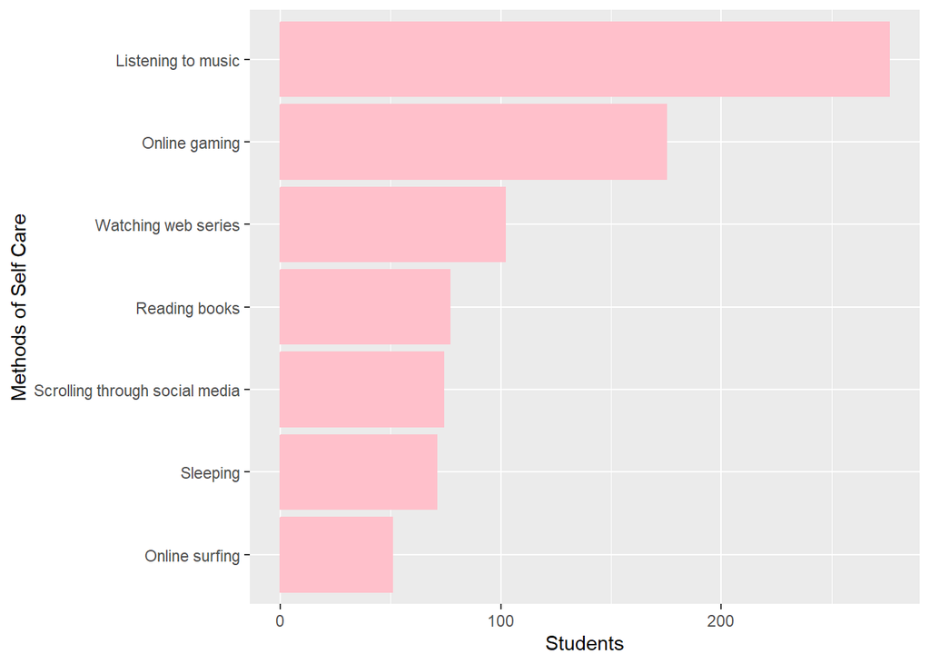

This chart was included because I wanted to know the most popular ways in which students tended to their mental health through self-care. We believe that there are many ways to take care of one’s mental health that they can do either at home or by themselves. This bar graph reveals the top 7 methods that people do to take care of their mental health. I also chose a horizontal bar graph to make the groups more readable. In addition, I saw students liked listening to music, playing video games, and more.

## Chart 2

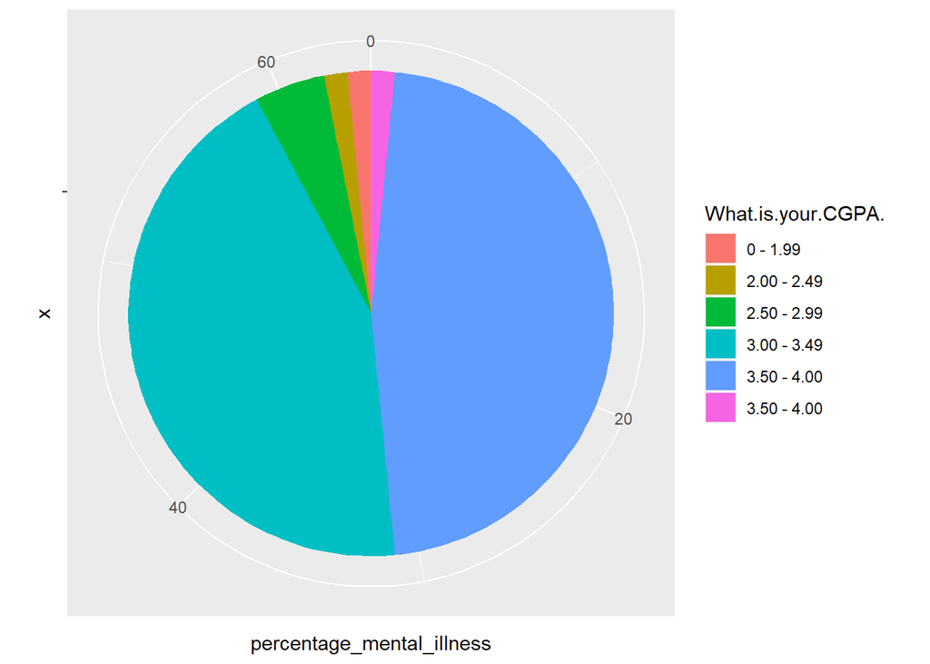

We decided to use a pie chart because we wanted to explore how one’s GPA influences student’s mental health brought by academic pressure. This pie chart depicts the relationship between student’s CGPA and their mental health condition. It mainly uses the column of three different mental conditions (depression, anxiety and panic attack) and CGPA. The final result shows that students with a higher CGPA normally are more likely to have one of these conditions. Maintaining a high GPA is hard and stressful.